# Final Project - Intro to Data Science

## 1. Final Project Data Science Hacktiv8 Batch 30

**Intro to Data Science prepared by Almas Shabrina**

**About Data**

This Data presented about Kickstarter project that has been launched since 1970-01-01 - 2018-01-02 base on dataseet that I've downloaded from https://www.kaggle.com/kemical/kickstarter-projects. Because of Kickstarter is established in 2009 but i found the minumum project launched year is 1970 (by temp_launched.agg("min") is 1970-01-01), therefore, I will only use data from the project deadline time since 2016 - 2017. There will be some slicing and data cleaning process.

**Kickstarter** is an American public benefit corporation based in Brooklyn, New York, that maintains a global crowdfunding platform focused on creativity. The company's stated mission is to "help bring creative projects to life. Kickstarter launch, on April 28, 2009, 18 million people have backed a project, $4.9 billion has been pledged, and 179,812 projects have been successfully funded.

**Topic covered and question to answer from the data:**

1. Which project category has the highest success rate?
2. What is the average fund collected by all projects?
3. What is the average fund for a successful project to be funded?
4. What is the average success rate of a successful project
5. What is the average project success rate?
6. Which country has the highest succes rate?
7. Which country has the most projects?
8. Is there an corelation on the duration with the amount of funds collected?
9. Is there a correlation between the duration of the project and the success rate?
10. Is there a correlation between the amount of funds collected and total backers?
11. What causes the project to fail?
12. What causes the project to be successful?

### 1.1 Data Understanding - Description Columns

1. ID - internal kickstarter id
2. name - name of project - A project is a finite work with a clear goal that you’d like to bring to life. Think albums, books, or films.
3. category - category
4. main_category - category of campaign
5. currency - currency used to support
6. deadline - deadline for crowdfunding
7. goal - The funding goal is the amount of money that a creator needs to complete their project.
8. launched - date launched
9. pledged - amount pledged by "crowd"
10. state - Current condition the project is in
11. backers - number of backers
12. country - country pledged from
13. usd_pledged - Pledged amount in USD (conversion made by Kickstater)
14. usd_pledge_real - Pledged amount in USD (conversion made by fixer.io api)
15. usd_goal_real - conversion in US dollars of the goal column, Goal amount in USD

Note :

- H0. Dependent Variable is State
- H1. Independent Variables are variables other than State

### 1.2 Data Exploring

To find out what data is available from the given dataset, such as values, data types, number of columns and rows.

```python
import numpy as np
import pandas as pd
import scipy.stats
from sklearn import preprocessing
import matplotlib as mpl
import matplotlib.pyplot as plt
plt.style.use('ggplot')
%matplotlib inline
```

```python
#import dataset
df = pd.read_csv('ks-projects-201801.csv')
df.head(3)
```

|  | ID | name | category | main_category | currency | deadline | goal | launched | pledged | state | backers | country | usd pledged | usd_pledged_real | usd_goal_real |
| --- | --- | --- | --- | --- | --- | --- | --- | --- | --- | --- | --- | --- | --- | --- | --- |
| 0 | 1000002330 | The Songs of Adelaide & Abullah | Poetry | Publishing | GBP | 2015-10-09 | 1000.0 | 2015-08-11 12:12:28 | 0.0 | failed | 0 | GB | 0.0 | 0.0 | 1533.95 |
| 1 | 1000003930 | Greeting From Earth: ZGAC Arts Capsule For ET | Narrative Film | Film & Video | USD | 2017-11-01 | 30000.0 | 2017-09-02 04:43:57 | 2421.0 | failed | 15 | US | 100.0 | 2421.0 | 30000.00 |
| 2 | 1000004038 | Where is Hank? | Narrative Film | Film & Video | USD | 2013-02-26 | 45000.0 | 2013-01-12 00:20:50 | 220.0 | failed | 3 | US | 220.0 | 220.0 | 45000.00 |

```python
#check number of rows and columns
df.shape
```

```
(378661, 15)
```

```python
#check isnull data from tabel
df.info()
```

```
<class 'pandas.core.frame.DataFrame'>
RangeIndex: 378661 entries, 0 to 378660
Data columns (total 15 columns):
ID                  378661 non-null int64
name                378657 non-null object
category            378661 non-null object
main_category       378661 non-null object
currency            378661 non-null object
deadline            378661 non-null object
goal                378661 non-null float64
launched            378661 non-null object
pledged             378661 non-null float64
state               378661 non-null object
backers             378661 non-null int64
country             378661 non-null object
usd pledged         374864 non-null float64
usd_pledged_real    378661 non-null float64
usd_goal_real       378661 non-null float64
dtypes: float64(5), int64(2), object(8)
memory usage: 43.3+ MB
```

```python
#finding invalid Data
df["launched"].agg(("min", "max"))
```

```
min    1970-01-01 01:00:00
max    2018-01-02 15:02:31
Name: launched, dtype: object
```

```python
#finding invalid Data
df["deadline"].agg(("min", "max"))
```

```
min    2009-05-03
max    2018-03-03
Name: deadline, dtype: object
```

### 1.3 Data Extracting

```python
#copiying Dataset
df_kickstarter = df.copy()

#get datetime data type, the value of the column is sliced, then convert to datetime data type.
temp_launched = df_kickstarter["launched"].str[:11]
temp_deadline = df_kickstarter["deadline"].str[:11]
df_kickstarter["launched"] = pd.to_datetime(temp_launched)
df_kickstarter["deadline"] = pd.to_datetime(temp_deadline)
df_kickstarter.head(3)
```

|  | ID | name | category | main_category | currency | deadline | goal | launched | pledged | state | backers | country | usd pledged | usd_pledged_real | usd_goal_real |
| --- | --- | --- | --- | --- | --- | --- | --- | --- | --- | --- | --- | --- | --- | --- | --- |
| 0 | 1000002330 | The Songs of Adelaide & Abullah | Poetry | Publishing | GBP | 2015-10-09 | 1000.0 | 2015-08-11 | 0.0 | failed | 0 | GB | 0.0 | 0.0 | 1533.95 |
| 1 | 1000003930 | Greeting From Earth: ZGAC Arts Capsule For ET | Narrative Film | Film & Video | USD | 2017-11-01 | 30000.0 | 2017-09-02 | 2421.0 | failed | 15 | US | 100.0 | 2421.0 | 30000.00 |
| 2 | 1000004038 | Where is Hank? | Narrative Film | Film & Video | USD | 2013-02-26 | 45000.0 | 2013-01-12 | 220.0 | failed | 3 | US | 220.0 | 220.0 | 45000.00 |

```python
# get year column from deadline column
df_kickstarter['year'] = df_kickstarter['deadline'].dt.year
df_kickstarter.shape
```

```
(378661, 16)
```

```python
#This Section will delete unnecessary rows.
##Delete rows, use data from 2016 - 2017 only
df_kickstarter=df_kickstarter[(df_kickstarter["year"]>= 2016) & (df_kickstarter["year"]<= 2017)]
df_kickstarter.shape
```

```
(110815, 16)
```

```python
#This Section will delete unnecessary columns.
## Delete columns
del_columns = ["ID", "name", "currency", "category", "goal", "pledged", "usd pledged"] #grouping unnecessary columns
df_kickstarter.drop(del_columns, inplace=True, axis=1)  #Deleting column
df_kickstarter.shape
```

```
(110815, 9)
```

```python
#This Section will canculate duration of project that had been launched.
##Duration obtined from deadline column - launched column
df_kickstarter['duration'] = df_kickstarter["deadline"] - df_kickstarter["launched"]

df_kickstarter
```

|  | main_category | deadline | launched | state | backers | country | usd_pledged_real | usd_goal_real | year | duration |
| --- | --- | --- | --- | --- | --- | --- | --- | --- | --- | --- |
| 1 | Film & Video | 2017-11-01 | 2017-09-02 | failed | 15 | US | 2421.00 | 30000.00 | 2017 | 60 days |
| 5 | Food | 2016-04-01 | 2016-02-26 | successful | 224 | US | 52375.00 | 50000.00 | 2016 | 35 days |
| 7 | Food | 2016-03-17 | 2016-02-01 | failed | 40 | US | 453.00 | 25000.00 | 2016 | 45 days |
| 13 | Games | 2016-03-25 | 2016-02-09 | failed | 0 | US | 0.00 | 200000.00 | 2016 | 45 days |
| 14 | Games | 2017-05-03 | 2017-04-05 | successful | 761 | GB | 121857.33 | 6469.73 | 2017 | 28 days |
| ... | ... | ... | ... | ... | ... | ... | ... | ... | ... | ... |
| 378648 | Games | 2016-02-23 | 2016-01-24 | canceled | 5 | US | 121.00 | 500.00 | 2016 | 30 days |
| 378649 | Film & Video | 2017-04-09 | 2017-02-08 | failed | 6 | US | 135.00 | 500.00 | 2017 | 60 days |
| 378650 | Technology | 2016-09-05 | 2016-07-29 | failed | 0 | US | 0.00 | 6000.00 | 2016 | 38 days |
| 378654 | Food | 2017-04-19 | 2017-03-20 | failed | 4 | US | 154.00 | 6500.00 | 2017 | 30 days |
| 378659 | Technology | 2016-02-13 | 2016-01-13 | failed | 6 | US | 200.00 | 15000.00 | 2016 | 31 days |

110815 rows × 10 columns

```python
#Check null data and data type
df_kickstarter.info()
```

```
<class 'pandas.core.frame.DataFrame'>
Int64Index: 110815 entries, 1 to 378659
Data columns (total 10 columns):
main_category       110815 non-null object
deadline            110815 non-null datetime64[ns]
launched            110815 non-null datetime64[ns]
state               110815 non-null object
backers             110815 non-null int64
country             110815 non-null object
usd_pledged_real    110815 non-null float64
usd_goal_real       110815 non-null float64
year                110815 non-null int64
duration            110815 non-null timedelta64[ns]
dtypes: datetime64[ns](2), float64(2), int64(2), object(3), timedelta64[ns](1)
memory usage: 9.3+ MB
```

```python
#reset index after deleted rows
df_kickstarter = df_kickstarter.reset_index(drop=True)
df_kickstarter.head()
```

|  | main_category | deadline | launched | state | backers | country | usd_pledged_real | usd_goal_real | year | duration |
| --- | --- | --- | --- | --- | --- | --- | --- | --- | --- | --- |
| 0 | Film & Video | 2017-11-01 | 2017-09-02 | failed | 15 | US | 2421.00 | 30000.00 | 2017 | 60 days |
| 1 | Food | 2016-04-01 | 2016-02-26 | successful | 224 | US | 52375.00 | 50000.00 | 2016 | 35 days |
| 2 | Food | 2016-03-17 | 2016-02-01 | failed | 40 | US | 453.00 | 25000.00 | 2016 | 45 days |
| 3 | Games | 2016-03-25 | 2016-02-09 | failed | 0 | US | 0.00 | 200000.00 | 2016 | 45 days |
| 4 | Games | 2017-05-03 | 2017-04-05 | successful | 761 | GB | 121857.33 | 6469.73 | 2017 | 28 days |

```python
df_kickstarter['duration'] = df_kickstarter['duration'].astype(int)
df_kickstarter['duration'] = df_kickstarter['duration'].astype(int) / 86400000000000
df_kickstarter.head()
```

|  | main_category | deadline | launched | state | backers | country | usd_pledged_real | usd_goal_real | year | duration |
| --- | --- | --- | --- | --- | --- | --- | --- | --- | --- | --- |
| 0 | Film & Video | 2017-11-01 | 2017-09-02 | failed | 15 | US | 2421.00 | 30000.00 | 2017 | 60.0 |
| 1 | Food | 2016-04-01 | 2016-02-26 | successful | 224 | US | 52375.00 | 50000.00 | 2016 | 35.0 |
| 2 | Food | 2016-03-17 | 2016-02-01 | failed | 40 | US | 453.00 | 25000.00 | 2016 | 45.0 |
| 3 | Games | 2016-03-25 | 2016-02-09 | failed | 0 | US | 0.00 | 200000.00 | 2016 | 45.0 |
| 4 | Games | 2017-05-03 | 2017-04-05 | successful | 761 | GB | 121857.33 | 6469.73 | 2017 | 28.0 |

## 2. Deskripsi Data

Determine the data center and the distribution of data that has been extracted, for instance, mean, median, mode, data outlier, and distribution. Create another data frame if needed to gain insight and references to prove a hypothesis.

### 2.1 Main_category Variable

is a variable that divides the project into several main categories.

```python
#find and count value from main category column
df_category = df_kickstarter["main_category"].value_counts()
df_category
```

```
Games           13884
Technology      13249
Film & Video    12657
Design          11888
Publishing      11072
Music           10864
Fashion          8405
Art              7587
Food             7152
Comics           3871
Crafts           3385
Photography      2418
Theater          2055
Journalism       1511
Dance             817
Name: main_category, dtype: int64
```

There are 15 main categories for all projects deadline time at kickstarter from 2016 - 2017, this data includes for all project statuses. The category with the highest score is Games with 13884 projects and the least is Dance with 817 projects.

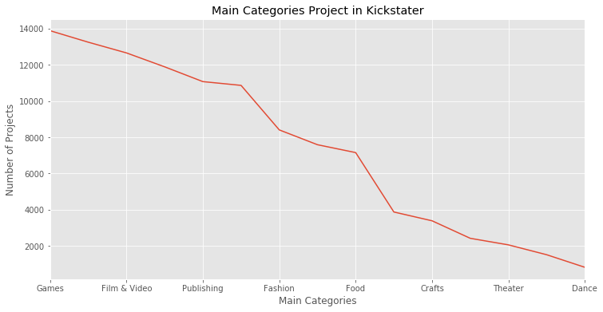

```python
#Create plot line that represent data from main category column
df_category.plot(figsize = (12,6))
plt.title('Main Categories Project in Kickstater')
plt.ylabel('Number of Projects')
plt.xlabel('Main Categories')
```

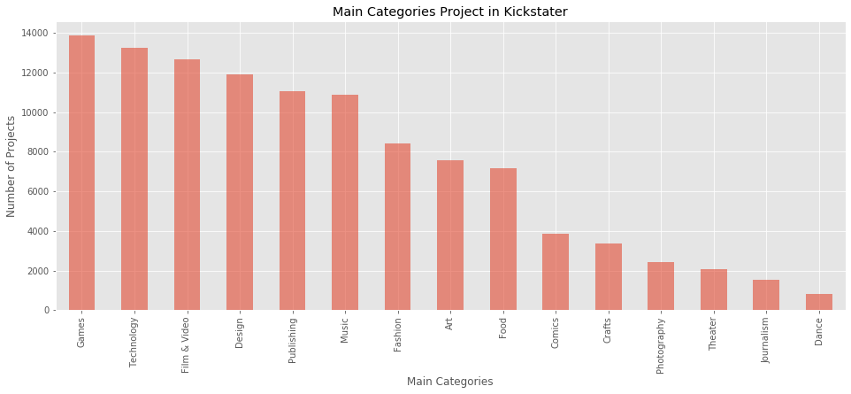

```python
#Create plot bar that represent data from main category column
df_kickstarter["main_category"].value_counts().plot(figsize=(16,6), kind="bar",  alpha=0.6)
plt.title('Main Categories Project in Kickstater')
plt.ylabel('Number of Projects')
plt.xlabel('Main Categories')
```

**Graph Description :** The graph above shows the number and categories of what is in the main category table without any grouping whether the project is considered successful or failed. The grouping of categories based on their status will be shown below.

**Grouping data to get other insight**

```python
#group and count main categori base on its state
state_by_category = df_kickstarter.groupby(['main_category']) ['state'].value_counts()
state_by_category_1 = pd.DataFrame (state_by_category) #save into datarame
print(state_by_category_1)
```

```
                          state
main_category state
Art           failed       3837
              successful   3041
              canceled      670
              suspended      39
Comics        successful   2361
...                         ...
Technology    live            2
Theater       successful   1180
              failed        732
              canceled      142
              suspended       1

[71 rows x 1 columns]
```

```python
df_kickstarter["state"].value_counts()
```

```
failed        58155
successful    38172
canceled      13178
suspended       707
undefined       596
live              7
Name: state, dtype: int64
```

```python
#Create Series consist of main category and group by state as described above
successful = df_kickstarter.loc[df_kickstarter["state"] == "successful", "main_category"].value_counts()
failed = df_kickstarter.loc[df_kickstarter["state"] == "failed", "main_category"].value_counts()
canceled = df_kickstarter.loc[df_kickstarter["state"] == "canceled", "main_category"].value_counts()
suspended = df_kickstarter.loc[df_kickstarter["state"] == "suspended", "main_category"].value_counts()
live = df_kickstarter.loc[df_kickstarter["state"] == "live", "main_category"].value_counts()
undefined = df_kickstarter.loc[df_kickstarter["state"] == "undefined", "main_category"].value_counts()
```

```python
#Create another Data Frame to store data from Series that have been extracted above
df_category=pd.DataFrame(df_category)
df_category["successful"] = successful
df_category["failed"] = failed
df_category["canceled"] = canceled
df_category["suspended"] = suspended
df_category["undefined"] = undefined
df_category["live"] = live

#renama column main category to Total state
df_category = df_category.rename(columns={"main_category": "Total State"})

#Replace null value with 0 value
df_category.fillna(0, inplace=True)
df_category
```

|  | Total State | successful | failed | canceled | suspended | undefined | live |
| --- | --- | --- | --- | --- | --- | --- | --- |
| Games | 13884 | 5556 | 5770 | 2478 | 79 | 1.0 | 0.0 |
| Technology | 13249 | 2563 | 8505 | 1979 | 200 | 0.0 | 2.0 |
| Film & Video | 12657 | 4442 | 6712 | 1344 | 45 | 113.0 | 1.0 |
| Design | 11888 | 4521 | 5388 | 1867 | 110 | 1.0 | 1.0 |
| Publishing | 11072 | 3763 | 6107 | 1078 | 22 | 102.0 | 0.0 |
| Music | 10864 | 4634 | 5002 | 801 | 48 | 377.0 | 2.0 |
| Fashion | 8405 | 2139 | 5205 | 1012 | 47 | 2.0 | 0.0 |
| Art | 7587 | 3041 | 3837 | 670 | 39 | 0.0 | 0.0 |
| Food | 7152 | 1553 | 4877 | 669 | 52 | 0.0 | 1.0 |
| Comics | 3871 | 2361 | 1204 | 301 | 5 | 0.0 | 0.0 |
| Crafts | 3385 | 826 | 2168 | 363 | 28 | 0.0 | 0.0 |
| Photography | 2418 | 839 | 1321 | 242 | 16 | 0.0 | 0.0 |
| Theater | 2055 | 1180 | 732 | 142 | 1 | 0.0 | 0.0 |
| Journalism | 1511 | 274 | 1038 | 186 | 13 | 0.0 | 0.0 |
| Dance | 817 | 480 | 289 | 46 | 2 | 0.0 | 0.0 |

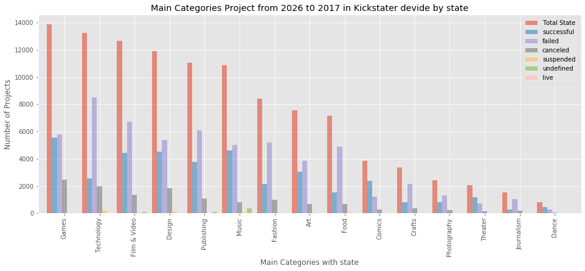

```python
#Create Group Bar Graphic from main categori and state in df_category Data Frame
df_category.plot(kind="bar", figsize = (16,6), alpha=0.6, width=1)
plt.title('Main Categories Project from 2026 t0 2017 in Kickstater devide by state')
plt.ylabel('Number of Projects')
plt.xlabel('Main Categories with state')
```

### 2.2 Dealine Variable

we specify the deadline variable, only the projects deadline from 2016 to 2017. Here we slice the data from main Data frame df_kickstarter

```python
#Get month column from deadline column
df_kickstarter['month_dl'] = df_kickstarter['deadline'].dt.month
df_kickstarter.head(3)
```

|  | main_category | deadline | launched | state | backers | country | usd_pledged_real | usd_goal_real | year | duration | month_dl |
| --- | --- | --- | --- | --- | --- | --- | --- | --- | --- | --- | --- |
| 0 | Film & Video | 2017-11-01 | 2017-09-02 | failed | 15 | US | 2421.0 | 30000.0 | 2017 | 60.0 | 11 |
| 1 | Food | 2016-04-01 | 2016-02-26 | successful | 224 | US | 52375.0 | 50000.0 | 2016 | 35.0 | 4 |
| 2 | Food | 2016-03-17 | 2016-02-01 | failed | 40 | US | 453.0 | 25000.0 | 2016 | 45.0 | 3 |

```python
#Get number of project deadline group by month in 2016
temp_2016 = df_kickstarter.loc[df_kickstarter["year"] == 2016, "month_dl"].value_counts()

#Get number of project deadline group by month in 2016
temp_2017 = df_kickstarter.loc[df_kickstarter["year"] == 2017, "month_dl"].value_counts()
```

[output not shown]

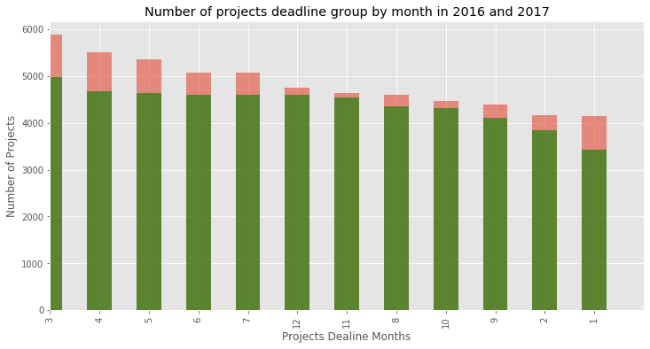

```python
#Create plot line to represent data from project deadline group by month in 2016 and 2017
temp_2016.plot(kind="bar", figsize=(12,6), alpha=0.6) #blue
temp_2017.plot(kind="bar", figsize=(12,6), color="green", alpha=0.6)
plt.title('Number of projects deadline group by month in 2016 and 2017')
plt.ylabel('Number of Projects')
plt.xlabel('Projects Dealine Months')
plt.xlim(0,12)
```

**Diagram description :** the highest number of Projects deadline accoured beetween the end of Q1 and Q2 every year.

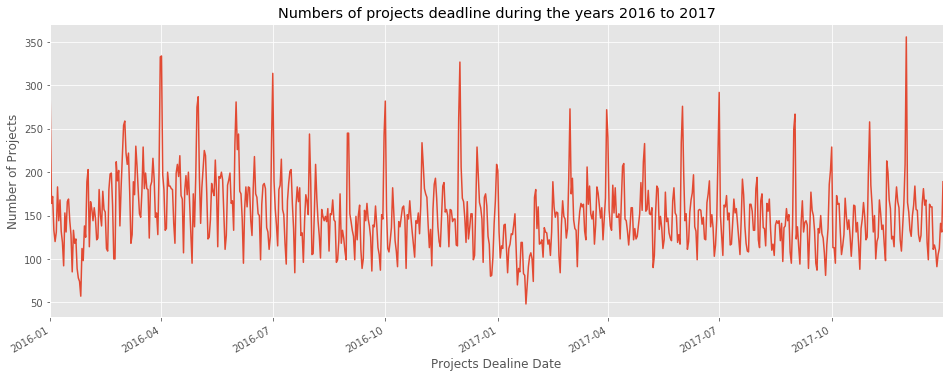

```python
#Create plot line to represent data from project deadline during the years 2016 to 2017
deadline = df_kickstarter["deadline"].value_counts().plot(figsize=(16,6))
plt.title('Numbers of projects deadline during the years 2016 to 2017')
plt.ylabel('Number of Projects')
plt.xlabel('Projects Dealine Date')
```

**Diagram description :** the highest number of Projects occured beetween the end of Q1, during Q2, and the end of Q4, with total of project is 356 per day.

```python
#Show the information of tabel deadline
df_kickstarter["deadline"].describe()
```

```
count                  110815
unique                    731
top       2017-12-01 00:00:00
freq                      356
first     2016-01-01 00:00:00
last      2017-12-31 00:00:00
Name: deadline, dtype: object
```

```python
#Calculate average project deadline per day
unique = 731 #total of days
mean_project = len(df_kickstarter["deadline"]) / unique
print("average number of projects deadline time : ", mean_project)
```

```
average number of projects deadline time :  151.593707250342
```

### 2.3 Launched Variable

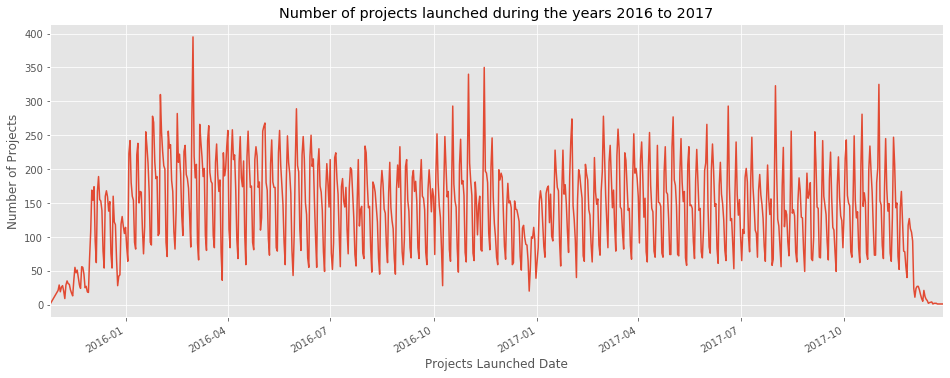

```python
#Create plot line to represent data from project deadline during the years 2016 to 2017
df_kickstarter["launched"].value_counts().plot(figsize=(16,6))
plt.title('Number of projects launched during the years 2016 to 2017')
plt.ylabel('Number of Projects')
plt.xlabel('Projects Launched Date')
```

**Diagram description :** the highest number of Projects occured beetween the end of Q1 and Q4.

```python
#Show the information of tabel launched
df_kickstarter["launched"].describe()
```

```
count                  110815
unique                    785
top       2016-03-01 00:00:00
freq                      395
first     2015-10-26 00:00:00
last      2017-12-28 00:00:00
Name: launched, dtype: object
```

```python
#Calculate average project launched per day
unique = 785 #total of days you can find it in description above
mean_project = len(df_kickstarter["launched"]) / unique
print("average number of projects launcahed : ", mean_project)
```

```
average number of projects launcahed :  141.1656050955414
```

### 2.4 State Variable

```python
#get any value in the state table and calculate the total number of values
df_kickstarter["state"].value_counts()
```

```
failed        58155
successful    38172
canceled      13178
suspended       707
undefined       596
live              7
Name: state, dtype: int64
```

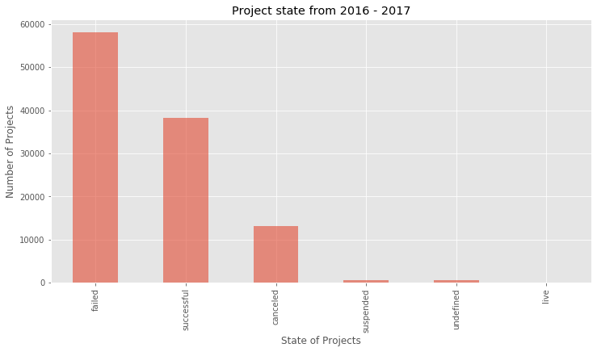

```python
#Create bar plot and represent any value from state column
df_kickstarter["state"].value_counts().plot(kind="bar", figsize=(12,6), alpha=0.6)
plt.title('Project state from 2016 - 2017')
plt.ylabel('Number of Projects')
plt.xlabel('State of Projects')
```

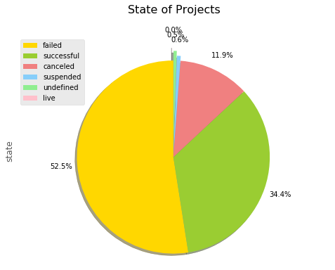

```python
#Create pie chart
results = df_kickstarter["state"].value_counts()
colors_list = ['gold', 'yellowgreen', 'lightcoral','lightskyblue', 'lightgreen', 'pink']
explode_list = [0, 0, 0, 0.05, 0.1, 0.15]

results.plot(kind='pie',
             figsize =(8,6),
             startangle=90,
             autopct='%1.1f%%',
             shadow=True,
             labels=None,
             pctdistance=1.17,
             colors=colors_list,
             explode=explode_list
            )

plt.title('State of Projects', fontsize = 16, y=1.08)
plt.axis('equal')
plt.legend(labels=results.index, loc='upper left')

plt.show()
```

**Diagram description :** The following is the percentage of project status are failed (52.5%), suucessful (344.4%), canceled (11.9%), suspended (0.6%), undefined (0.5%) and live (0.0%)

### 2.5 backers Variable

```python
#show the information of tabel backers
df_kickstarter["backers"].describe()
```

```
count    110815.000000
mean        125.900636
std         918.070823
min           0.000000
25%           2.000000
50%          11.000000
75%          60.000000
max      154926.000000
Name: backers, dtype: float64
```

From the description above, we get the largest number of backers is 154926 in 1 project, from the standard deviation value that we get, we know there is an outlier with extreme values. More details are illustrated in the boxplot graph below.

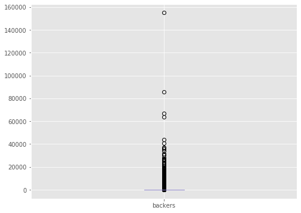

```python
df_kickstarter.boxplot(column=["backers"], figsize=(8, 6))
```

### 2.6 country Variable

Country code for projects on Kickstarter

```python
#Get number of each country
df_kickstarter["country"].value_counts()
```

```
US      71905
GB      11991
CA       5555
AU       3181
DE       2865
IT       2195
FR       2084
ES       1741
MX       1633
NL       1124
SE        982
N,0"      816
CH        611
NZ        607
DK        597
HK        577
SG        523
IE        466
BE        465
AT        443
NO        378
LU         47
JP         29
Name: country, dtype: int64
```

**Description :** The country with the most projects is the US or America with a total project during 2016 - 2017 is 71905 projects, and the least is JP or Japan with 29 projects.

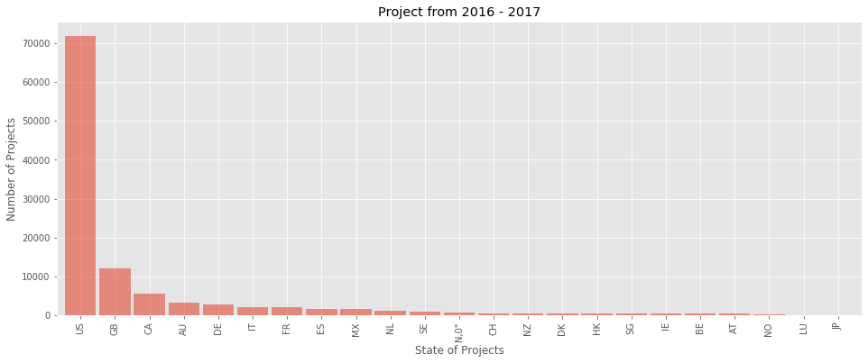

```python
#Create bar chart to represent any data in country table
df_kickstarter["country"].value_counts().plot(kind="bar", figsize=(16,6), alpha=0.6, width=0.9)
plt.title('Project from 2016 - 2017')
plt.ylabel('Number of Projects')
plt.xlabel('State of Projects')
```

**Diagram description :** The chart above is number of country in kickstarter project during 2016 - 2017. the largest number of projects is US and the least is JP.

### 2.7 usd_pledged_real Variable

funds that are actually collected

```python
#show the information of tabel usd_pledged_real
df_kickstarter["usd_pledged_real"].describe()
```

```
count    1.108150e+05
mean     1.170209e+04
std      1.043228e+05
min      0.000000e+00
25%      2.595500e+01
50%      5.500000e+02
75%      4.318320e+03
max      1.277984e+07
Name: usd_pledged_real, dtype: float64
```

From the description above, we get the largest amount of fund is USD 1.277984e+07 in 1 project, from the standard deviation value that we get, we know there is an outlier with extreme values. More details are illustrated in the boxplot graph below.

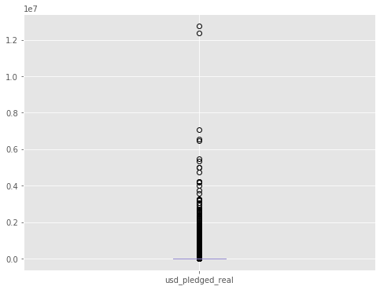

```python
df_kickstarter.boxplot(column=["usd_pledged_real"], figsize=(8, 6))
```

**Description :** from the diagram above, there are several outliers in usd_pledged_real variable, this outliyer will affect the mean value (mean), and the data distribution for this variable is not normal distribution. In the next section the usd_pledged_real variable will be divided according to the project state variable to look for insight.

```python
# create line plot and sort by amount of funds is pledged
usd_pledged_real = df_kickstarter["usd_pledged_real"].sort_values().reset_index(drop=True)
usd_pledged_real.head(3)
```

```
0    0.0
1    0.0
2    0.0
Name: usd_pledged_real, dtype: float64
```

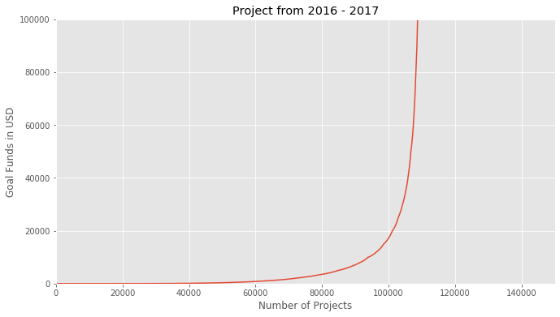

```python
# create line plot and sort by amount of funds is pledged
usd_pledged_real.plot(figsize=(11,6))
plt.ylim(0,100000) #set y max value to see the increaring line
plt.xlim(0,150000) #set x max value to see the increaring line
plt.title('Project from 2016 - 2017')
plt.xlabel('Number of Projects')
plt.ylabel('Goal Funds in USD')
```

**Diagram Description :** The line shows a straight comparison between the more the value of funds for a project, the more numbers of projects with large funds.

### 2.8 usd_goal_real Variable

targeted funds collected

```python
#show the information of tabel usd_goal_real
df_kickstarter["usd_goal_real"].describe()
```

```
count    1.108150e+05
mean     5.388820e+04
std      1.271062e+06
min      4.900000e-01
25%      2.000000e+03
50%      6.214070e+03
75%      2.000000e+04
max      1.073699e+08
Name: usd_goal_real, dtype: float64
```

From the description above, we get the largest amount of goal fund is USD 1.073699e+08 in 1 project, from the standard deviation value that we get, we know there is an outlier with extreme values. More details are illustrated in the boxplot graph below.

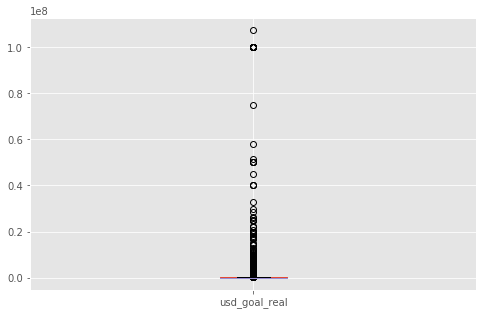

```python
df_kickstarter.boxplot(column=["usd_goal_real"], figsize=(8,5))
```

from the diagram above, there are several outliers in usd_goal_real variable, this outliyer will affect the mean value (mean), and the data distribution for this variable is not normal distribution. In the next section the usd_goal_real variable will be divided according to the project state variable to get the insight.

```python
# create line plot and sort by amount of funds goal of the project
usd_goal_real = df_kickstarter["usd_goal_real"].sort_values().reset_index(drop=True)
usd_goal_real.head(3)
```

```
0    0.49
1    0.55
2    0.73
Name: usd_goal_real, dtype: float64
```

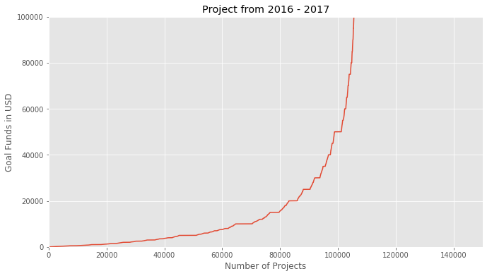

```python
# create line plot and sort by amount of funds goal of the project
usd_goal_real.plot(figsize=(11,6))
plt.ylim(0,100000) #set y max value to see the increaring line
plt.xlim(0,150000) #set x max value to see the increaring line
plt.title('Project from 2016 - 2017')
plt.xlabel('Number of Projects')
plt.ylabel('Goal Funds in USD')
```

**Diagram Description :** The line shows a straight comparison between the more the value of funds for a project, the more numbers of projects with large funds.

### 2.9 duration Variable

Deadline duration time for targeted funds collected

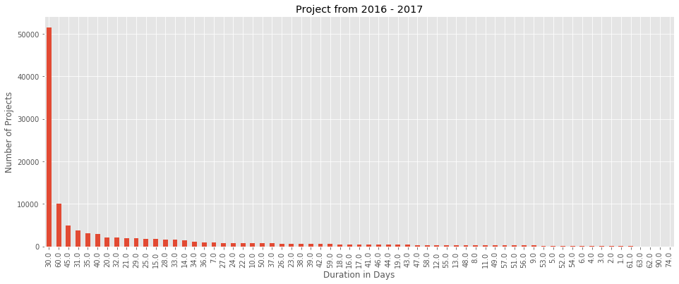

```python
#create bar chart to represent duration value from the largest to the smallest
df_kickstarter["duration"].value_counts().plot(kind="bar", figsize=(16,6))
plt.title('Project from 2016 - 2017')
plt.ylabel('Number of Projects')
plt.xlabel('Duration in Days')
```

```python
df_kickstarter["duration"].describe()
```

```
count    110815.000000
mean         33.156360
std          11.640658
min           1.000000
25%          30.000000
50%          30.000000
75%          35.000000
max          90.000000
Name: duration, dtype: float64
```

**Description :** The average project is open for 33 days, and most projects are in the duration of 30 days, the longest duration reaches 90 days and the fastest duration is 1 day.

## 3. Insight

This section will answer the following questions of data and gain insight and references to prove a hypothesis.

### 3.1 Which project category has the highest success rate?

**The explanation is below :**

```python
#create success_rt tabel to store success rate value
df_category["success_rt"] = df_category["successful"] / df_category["Total State"] * 100
```

```python
success_rt=df_category["success_rt"].sort_values(ascending=False, axis=0)
print("success rate by category is :")
success_rt
```

```
success rate by category is :
```

```
Comics          60.991992
Dance           58.751530
Theater         57.420925
Music           42.654639
Art             40.081719
Games           40.017286
Design          38.029946
Film & Video    35.095204
Photography     34.698098
Publishing      33.986633
Fashion         25.449137
Crafts          24.401773
Food            21.714206
Technology      19.344856
Journalism      18.133686
Name: success_rt, dtype: float64
```

```python
df_category.describe()
```

|  | Total State | successful | failed | canceled | suspended | undefined | live | success_rt |
| --- | --- | --- | --- | --- | --- | --- | --- | --- |
| count | 15.000000 | 15.00000 | 15.000000 | 15.000000 | 15.000000 | 15.000000 | 15.000000 | 15.000000 |
| mean | 7387.666667 | 2544.80000 | 3877.000000 | 878.533333 | 47.133333 | 39.733333 | 0.466667 | 36.718109 |
| std | 4710.155983 | 1711.22626 | 2559.984989 | 748.032550 | 51.757493 | 100.579369 | 0.743223 | 13.958219 |
| min | 817.000000 | 274.00000 | 289.000000 | 46.000000 | 1.000000 | 0.000000 | 0.000000 | 18.133686 |
| 25% | 2901.500000 | 1009.50000 | 1262.500000 | 271.500000 | 14.500000 | 0.000000 | 0.000000 | 24.925455 |
| 50% | 7587.000000 | 2361.00000 | 4877.000000 | 670.000000 | 39.000000 | 0.000000 | 0.000000 | 35.095204 |
| 75% | 11480.000000 | 4102.50000 | 5579.000000 | 1211.000000 | 50.000000 | 1.500000 | 1.000000 | 41.368179 |
| max | 13884.000000 | 5556.00000 | 8505.000000 | 2478.000000 | 200.000000 | 377.000000 | 2.000000 | 60.991992 |

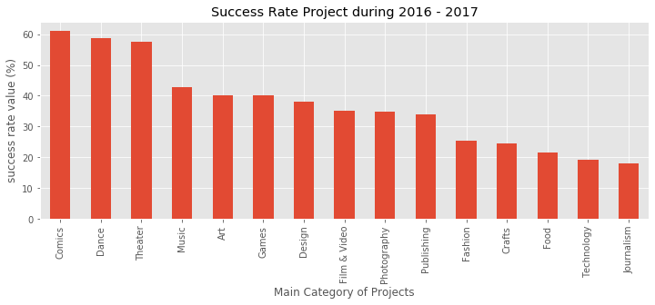

```python
#Create Bar diagram and sort the result
df_category["success_rt"].sort_values(ascending=False, axis=0).plot(kind="bar", figsize=(12,4))
plt.title('Success Rate Project during 2016 - 2017')
plt.ylabel('success rate value (%)')
plt.xlabel('Main Category of Projects')
```

This diagram show project sequences from biggest to smallest success, with the highest percentage for Comics. Here id the Detail:

1. Comics 60.991992
2. Dance 58.751530
3. Theater 57.420925
4. Music 42.654639
5. Art 40.081719
6. Games 40.017286
7. Design 38.029946
8. Film & Video 35.095204
9. Photography 34.698098
10. Publishing 33.986633
11. Fashion 25.449137
12. Crafts 24.401773
13. Food 21.714206
14. Technology 19.344856
15. Journalism 18.133686

**Failed Rate**

So we can conclude that the project with the highest failed rate is the project that has the lowest success rate, namely Food & Technology, and Journalist.

**Explanation is below.**

```python
#create failed_rt tabel to store success rate value
df_category_failed_rt = df_category["failed"] / df_category["Total State"] * 100
df_category_failed_rt.sort_values(ascending=False, axis=0)
```

```
Journalism      68.696228
Food            68.190716
Technology      64.193524
Crafts          64.047267
Fashion         61.927424
Publishing      55.157153
Photography     54.631927
Film & Video    53.029944
Art             50.573349
Music           46.041973
Design          45.323015
Games           41.558629
Theater         35.620438
Dance           35.373317
Comics          31.103074
dtype: float64
```

### 3.2 What is the average success rate of a successful project

```python
print('While the average success rate for all categories is', df_category["success_rt"].mean())
```

```
While the average success rate for all categories is 36.71810863397875
```

### 3.3 What is the average fund collected by the main category project with the status of a successful project?

The total funds raised/pledged are far greater than the total funds targeted, the most funds collected are in the Games, Design, and Technology categories. This also applies to the average value the average funds raised/pledged are greater than the funds targeted, the most funds collected are in the Games, Design, and Technology categories.

**The explanation is below :**

```python
#Create pledged real column group by state = successfull and main category
success_pledged_real = df_kickstarter[
    df_kickstarter["state"] == "successful"
].groupby("main_category")["usd_pledged_real"].sum()

#Create goal real column group by state = successfull and main category
success_goal_real = df_kickstarter[
    df_kickstarter["state"] == "successful"
].groupby("main_category")["usd_goal_real"].sum()
```

```python
#Add column to df_category
df_category["fund_success"] = success_pledged_real
df_category["av_fund_success"] = df_category["fund_success"] / df_category["successful"]

df_category["success_goal"] = success_goal_real
df_category["av_success_goal"] = df_category["success_goal"] / df_category["successful"]
```

```python
df_category.head(3)
```

|  | Total State | successful | failed | canceled | suspended | undefined | live | success_rt | fund_success | av_fund_success | success_goal | av_success_goal |
| --- | --- | --- | --- | --- | --- | --- | --- | --- | --- | --- | --- | --- |
| Games | 13884 | 5556 | 5770 | 2478 | 79 | 1.0 | 0.0 | 40.017286 | 2.864623e+08 | 51559.095137 | 63142030.65 | 11364.656344 |
| Technology | 13249 | 2563 | 8505 | 1979 | 200 | 0.0 | 2.0 | 19.344856 | 2.676737e+08 | 104437.638096 | 64804909.76 | 25284.787265 |
| Film & Video | 12657 | 4442 | 6712 | 1344 | 45 | 113.0 | 1.0 | 35.095204 | 6.381955e+07 | 14367.299899 | 50341803.44 | 11333.139000 |

```python
df_category.describe()
```

|  | Total State | successful | failed | canceled | suspended | undefined | live | success_rt | fund_success | av_fund_success | success_goal | av_success_goal |
| --- | --- | --- | --- | --- | --- | --- | --- | --- | --- | --- | --- | --- |
| count | 15.000000 | 15.00000 | 15.000000 | 15.000000 | 15.000000 | 15.000000 | 15.000000 | 15.000000 | 1.500000e+01 | 15.000000 | 1.500000e+01 | 15.000000 |
| mean | 7387.666667 | 2544.80000 | 3877.000000 | 878.533333 | 47.133333 | 39.733333 | 0.466667 | 36.718109 | 7.873950e+07 | 24619.521461 | 2.586832e+07 | 9310.686583 |
| std | 4710.155983 | 1711.22626 | 2559.984989 | 748.032550 | 51.757493 | 100.579369 | 0.743223 | 13.958219 | 1.114936e+08 | 28565.964159 | 2.431135e+07 | 5585.848820 |
| min | 817.000000 | 274.00000 | 289.000000 | 46.000000 | 1.000000 | 0.000000 | 0.000000 | 18.133686 | 2.949442e+06 | 6144.670354 | 2.639334e+06 | 3347.738705 |
| 25% | 2901.500000 | 1009.50000 | 1262.500000 | 271.500000 | 14.500000 | 0.000000 | 0.000000 | 24.925455 | 1.000822e+07 | 8799.140786 | 6.526001e+06 | 5574.509505 |
| 50% | 7587.000000 | 2361.00000 | 4877.000000 | 670.000000 | 39.000000 | 0.000000 | 0.000000 | 35.095204 | 3.236856e+07 | 12722.216204 | 1.907545e+07 | 7609.680417 |
| 75% | 11480.000000 | 4102.50000 | 5579.000000 | 1211.000000 | 50.000000 | 1.500000 | 1.000000 | 41.368179 | 5.528748e+07 | 21350.571359 | 4.047100e+07 | 11348.897672 |
| max | 13884.000000 | 5556.00000 | 8505.000000 | 2478.000000 | 200.000000 | 377.000000 | 2.000000 | 60.991992 | 3.177450e+08 | 104437.638096 | 6.998769e+07 | 25284.787265 |

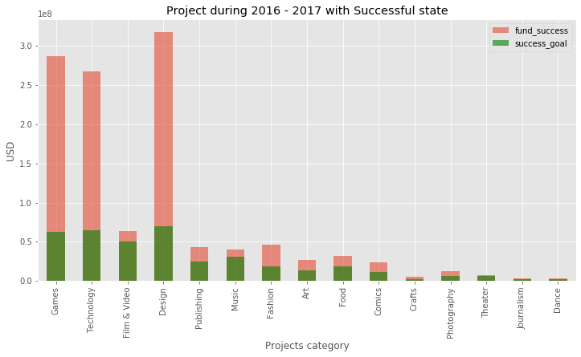

```python
#Create line plot to compare of goal fund and pledged fund project
df_category["fund_success"].plot(kind="bar", figsize=(12,5), alpha=0.6) #orange
df_category["success_goal"].plot(kind="bar", figsize=(12,6), color="green", alpha=0.6) #blue
plt.legend(loc='upper right')
plt.title('Project during 2016 - 2017 with Successful state')
plt.ylabel('USD')
plt.xlabel('Projects category')
```

This diagram shows a comparison between the Total funds collected and the total goal funds set. From this diagram we know that the funds raised are far greater than the funds targeted, the most total funds collected are in the Games, Design, and Technology categories.

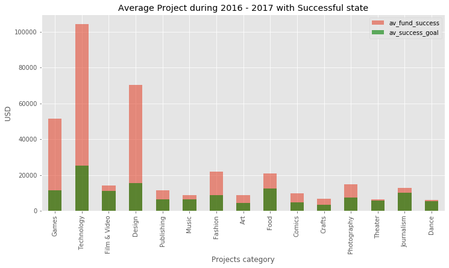

```python
#Create line plot to compare average of goal fund and pledged fund project
df_category["av_fund_success"].plot(kind="bar", figsize=(12,6), alpha=0.6)
df_category["av_success_goal"].plot(kind="bar", figsize=(12,6), color="green", alpha=0.6) #blue
plt.legend(loc='upper right')
plt.title('Average Project during 2016 - 2017 with Successful state')
plt.ylabel('USD')
plt.xlabel('Projects category')
```

This diagram shows a comparison between the average funds collected and the average goal funds set. From this diagram we know that the funds raised are far greater than the funds targeted, the most funds collected are in the Games, Design, and Technology categories. The diagram above is the average funding for a successful project.

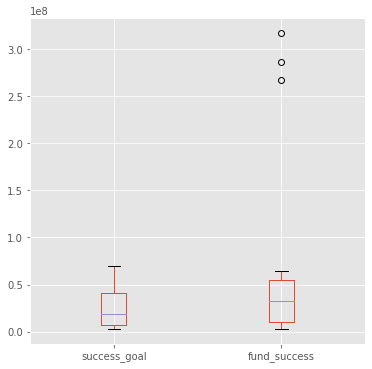

```python
#preview canter value
df_category.boxplot(column=["success_goal", "fund_success"], figsize=(6, 6))
```

there are outliers with extreme values which will affect the mean value of a calculation and statistical conclusion, but that's the real data.

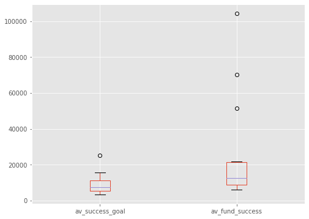

```python
#preview canter value
df_category.boxplot(column=["av_success_goal", "av_fund_success"], figsize=(8, 6))
```

there are outliers with extreme values which will affect the mean value of a calculation and statistical conclusion, but that's the real data.

```python
print("The average fund collected by main category projects with success is : ")
df_category["av_fund_success"]
```

```
The average fund collected by main category projects with success is :
```

```
Games            51559.095137
Technology      104437.638096
Film & Video     14367.299899
Design           70282.024189
Publishing       11521.885496
Music             8688.012378
Fashion          21858.539911
Art               8910.269194
Food             20842.602807
Comics            9959.696849
Crafts            6765.345133
Photography      14777.496484
Theater           6456.029788
Journalism       12722.216204
Dance             6144.670354
Name: av_fund_success, dtype: float64
```

```python
print("The average successful goal is set by : ")
df_category["av_success_goal"]
```

```
The average successful goal is set by :
```

```
Games           11364.656344
Technology      25284.787265
Film & Video    11333.139000
Design          15480.578157
Publishing       6505.390579
Music            6603.408095
Fashion          8917.929794
Art              4415.794311
Food            12376.627386
Comics           4936.544638
Crafts           3347.738705
Photography      7609.680417
Theater          5650.406907
Journalism      10335.005036
Dance            5498.612104
Name: av_success_goal, dtype: float64
```

### 2.4 What is the average fund collected by main category projects with failed state?

**The explanation is below :**

```python
#Create goal real column group by state = failed and main category
failed_goal_real = df_kickstarter[
    df_kickstarter["state"] == "failed"
].groupby("main_category")["usd_goal_real"].sum()

df_category["goal_failed"] = failed_goal_real
df_category["av_goal_failed"] = df_category["goal_failed"] / df_category["failed"]


failed_pledged = df_kickstarter[
    df_kickstarter["state"] == "failed"
].groupby("main_category")["usd_pledged_real"].sum()

df_category["fund_failed"] = failed_pledged
df_category["av_fund_failed"] = df_category["fund_failed"] / df_category["failed"]
```

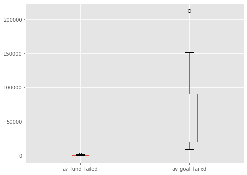

```python
#preview canter value
df_category.boxplot(column=["av_fund_failed", "av_goal_failed" ], figsize=(8, 6))
```

```python
print("The average fund goal collected by main category projects with failed state is : ")
df_category["av_goal_failed"].sort_values(ascending=False, axis=0)
```

```
The average fund goal collected by main category projects with failed state is :
```

```
Film & Video    212604.945894
Journalism      151502.446281
Art             104950.243941
Technology       95354.272234
Theater          85754.681284
Design           59522.447773
Games            58599.432636
Food             58519.596889
Music            38362.391028
Fashion          22224.914826
Publishing       20923.660596
Photography      19682.506109
Dance            17373.030415
Crafts           10526.511965
Comics            9861.947425
Name: av_goal_failed, dtype: float64
```

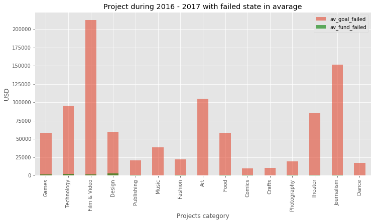

```python
#Create line plot to compare of Average goal fund and average pledged fund project
df_category["av_goal_failed"].plot(kind="bar", figsize=(12,5), alpha=0.6)
df_category["av_fund_failed"].plot(kind="bar", figsize=(12,6), color="green", alpha=0.6)
plt.legend(loc='upper right')
plt.title('Project during 2016 - 2017 with failed state in avarage')
plt.ylabel('USD')
plt.xlabel('Projects category')
```

This diagram shows a comparison between the average funds collected and the average goal funds set with failed status. From this diagram we know that the funds raised are far smaller than the funds targeted, the least funds collected and failed are in the Comics, Crafts, and Dance. The diagram above is the average funding for a failed project.

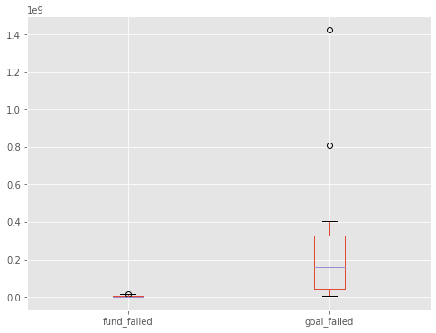

```python
#preview canter value
df_category.boxplot(column=["fund_failed", "goal_failed" ], figsize=(8, 6))
```

```python
print("The fund goal collected by main category projects with failed state is : ")
df_category["goal_failed"].sort_values(ascending=False, axis=0)
```

```
The fund goal collected by main category projects with failed state is :
```

```
Film & Video    1.427004e+09
Technology      8.109881e+08
Art             4.026941e+08
Games           3.381187e+08
Design          3.207069e+08
Food            2.854001e+08
Music           1.918887e+08
Journalism      1.572595e+08
Publishing      1.277808e+08
Fashion         1.156807e+08
Theater         6.277243e+07
Photography     2.600059e+07
Crafts          2.282148e+07
Comics          1.187378e+07
Dance           5.020806e+06
Name: goal_failed, dtype: float64
```

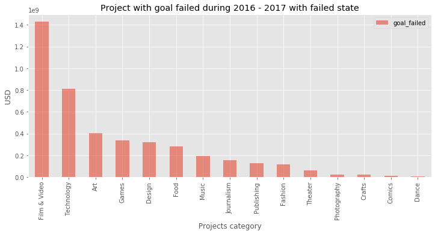

```python
#Create line plot to compare of goal fund and pledged fund project
df_category["goal_failed"].sort_values(ascending=False, axis=0).plot(kind="bar", figsize=(12,5), alpha=0.6)
plt.legend(loc='upper right')
plt.title('Project with goal failed during 2016 - 2017 with failed state')
plt.ylabel('USD')
plt.xlabel('Projects category')
```

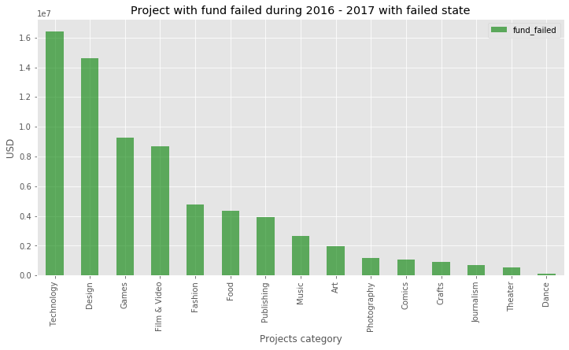

```python
df_category["fund_failed"].sort_values(ascending=False, axis=0).plot(kind="bar", figsize=(12,6), color="green", alpha=0.6)
plt.legend(loc='upper right')
plt.title('Project with fund failed during 2016 - 2017 with failed state')
plt.ylabel('USD')
plt.xlabel('Projects category')
```

This diagram shows the total amount of funds collected failed status. From this diagram we know that the funds raised are far smaller than the funds targeted, the least funds collected and failed are in the Journalist, Theater and Dance. The diagram above is the total amount of funding collected but project failed.

### 2.5 Which country has the highest succes rate?

**The explanation is below :**

```python
#Create dataframe consist of country and group by state
df_country_success = df_kickstarter.loc[df_kickstarter["state"] == "successful", "country"].value_counts()
df_country=pd.DataFrame(df_country_success)

#get number of projects with successful satet per country
df_country = df_country.rename(columns={"country": "success state"})

#get number of projects per country
df_country_all = df_kickstarter["country"].value_counts()
df_country["all state"] = df_country_all

#get success rate compared to all existing projects per country
df_country["success_rt_country"] = df_country["success state"] /  df_country["all state"]  * 100

#get success rate per country compared to all existing projects
df_country["success_rt_all"] = df_country["success state"] / len(df_kickstarter) * 100

df_country
```

|  | success state | all state | success_rt_country | success_rt_all |
| --- | --- | --- | --- | --- |
| US | 25413 | 71905 | 35.342466 | 22.932816 |
| GB | 5020 | 11991 | 41.864732 | 4.530073 |
| CA | 1861 | 5555 | 33.501350 | 1.679376 |
| AU | 999 | 3181 | 31.405218 | 0.901503 |
| DE | 737 | 2865 | 25.724258 | 0.665072 |
| FR | 700 | 2084 | 33.589251 | 0.631683 |
| ES | 423 | 1741 | 24.296381 | 0.381717 |
| MX | 395 | 1633 | 24.188610 | 0.356450 |
| IT | 378 | 2195 | 17.220957 | 0.341109 |
| NL | 340 | 1124 | 30.249110 | 0.306818 |
| SE | 334 | 982 | 34.012220 | 0.301403 |
| DK | 229 | 597 | 38.358459 | 0.206651 |
| NZ | 222 | 607 | 36.573311 | 0.200334 |
| HK | 216 | 577 | 37.435009 | 0.194919 |
| SG | 178 | 523 | 34.034417 | 0.160628 |
| CH | 165 | 611 | 27.004910 | 0.148897 |
| IE | 136 | 466 | 29.184549 | 0.122727 |
| BE | 131 | 465 | 28.172043 | 0.118215 |
| NO | 98 | 378 | 25.925926 | 0.088436 |
| N,0" | 91 | 816 | 11.151961 | 0.082119 |
| AT | 84 | 443 | 18.961625 | 0.075802 |
| LU | 15 | 47 | 31.914894 | 0.013536 |
| JP | 7 | 29 | 24.137931 | 0.006317 |

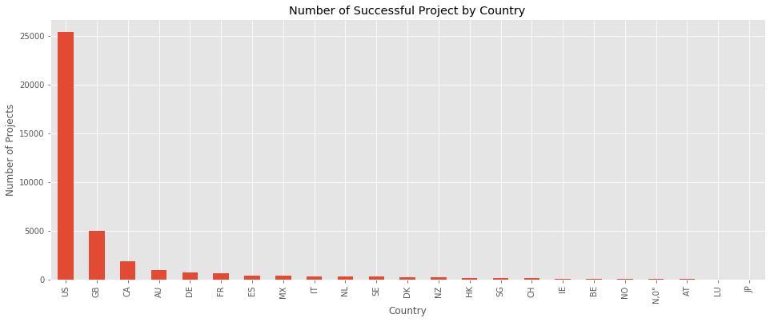

```python
#Create Number of Successful Project by Country
df_country["success state"].plot(kind="bar", figsize=(16,6))
plt.title('Number of Successful Project by Country')
plt.ylabel('Number of Projects')
plt.xlabel('Country')
```

**Diagram description :** The country with the most total projects with successful state is US, GB amd CA.

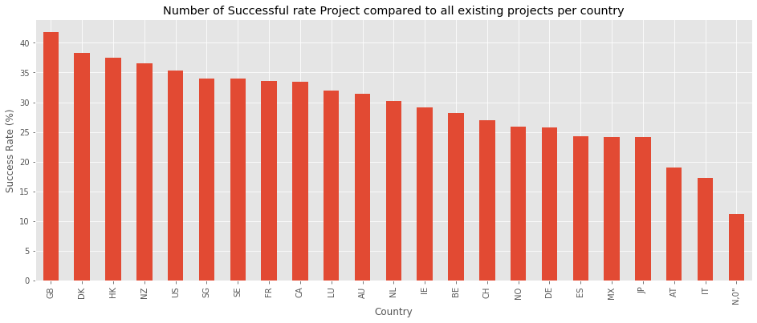

```python
#Create Successful rate Project compared to all existing projects per country
df_country["success_rt_country"].sort_values(ascending=False, axis=0).plot(kind="bar", figsize=(16,6))
plt.title('Number of Successful rate Project compared to all existing projects per country')
plt.ylabel('Success Rate (%)')
plt.xlabel('Country')
```

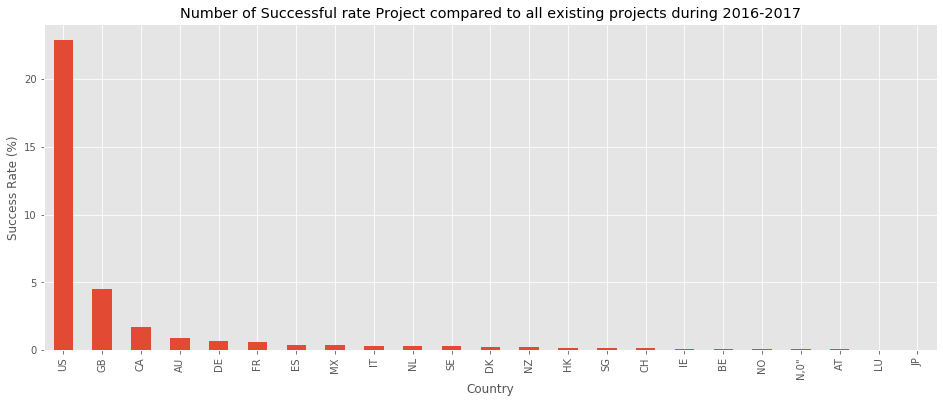

```python
#Create Successful rate Project compared to all existing projects during 2016-2017
df_country["success_rt_all"].sort_values(ascending=False, axis=0).plot(kind="bar", figsize=(16,6))
plt.title('Number of Successful rate Project compared to all existing projects during 2016-2017')
plt.ylabel('Success Rate (%)')
plt.xlabel('Country')
```

**Diagram description :** The country with the most total projects with successful compare to all state is US, GB amd CA.

### 2.6 Which project has the best and the worst duration?

Furthermore we will examine whether there is a correlation between successful projects with duration.

```python
#Create dataframe consist of duration and group by state
df_duration_success = df_kickstarter.loc[df_kickstarter["state"] == "successful", "duration"].value_counts()
df_duration_failed = df_kickstarter.loc[df_kickstarter["state"] == "failed", "duration"].value_counts()
df_duration_all = df_duration_success+df_duration_failed

df_duration=pd.DataFrame(df_duration_success)
df_duration["all duration"] = df_duration_all
df_duration["failed duration"] = df_duration_failed
df_duration = df_duration.rename(columns={"duration": "success duration"})

##df_duration.fillna(1, inplace=True)
df_duration["success_rt"] = df_duration["success duration"] / df_duration["all duration"] * 100
df_duration["failed_rt"] = df_duration["failed duration"] / df_duration["all duration"] * 100

df_duration
```

|  | success duration | all duration | failed duration | success_rt | failed_rt |
| --- | --- | --- | --- | --- | --- |
| 30.0 | 15669 | 44910.0 | 29241 | 34.889780 | 65.110220 |
| 31.0 | 1968 | 3359.0 | 1391 | 58.588866 | 41.411134 |
| 60.0 | 1519 | 8331.0 | 6812 | 18.233105 | 81.766895 |
| 45.0 | 1290 | 4142.0 | 2852 | 31.144375 | 68.855625 |
| 35.0 | 1196 | 2632.0 | 1436 | 45.440729 | 54.559271 |
| ... | ... | ... | ... | ... | ... |
| 2.0 | 17 | 38.0 | 21 | 44.736842 | 55.263158 |
| 3.0 | 17 | 55.0 | 38 | 30.909091 | 69.090909 |
| 1.0 | 15 | 31.0 | 16 | 48.387097 | 51.612903 |
| 61.0 | 6 | 28.0 | 22 | 21.428571 | 78.571429 |
| 63.0 | 1 | 2.0 | 1 | 50.000000 | 50.000000 |

62 rows × 5 columns

```python
#delete NaN value
df_duration=df_duration.dropna(axis=0)

df_duration["success_rt"].sort_values(ascending=False, axis=0)
```

```
22.0    64.469914
23.0    63.939900
11.0    63.131313
24.0    63.031161
17.0    62.972292
          ...
58.0    27.272727
59.0    27.209302
57.0    25.748503
61.0    21.428571
60.0    18.233105
Name: success_rt, Length: 62, dtype: float64
```

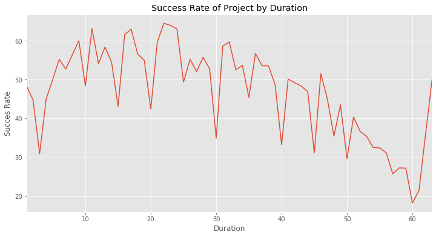

```python
df_duration["success_rt"].sort_index(ascending=False, axis=0).plot(figsize=(12,6))
plt.title('Success Rate of Project by Duration')
plt.ylabel('Succes Rate')
plt.xlabel('Duration')
```

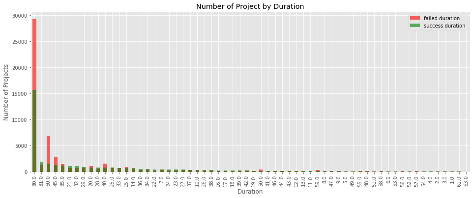

```python
df_duration["failed duration"].plot(kind="bar", figsize=(16,6), color="red", alpha=0.6)
df_duration["success duration"].plot(kind="bar", figsize=(16,6), color="green", alpha=0.6)
#plt.ylim(0,10000) # set max y axis
#plt.xlim(0,10) # set max x axis
plt.legend()
plt.title('Number of Project by Duration')
plt.ylabel('Number of Projects')
plt.xlabel('Duration')
```

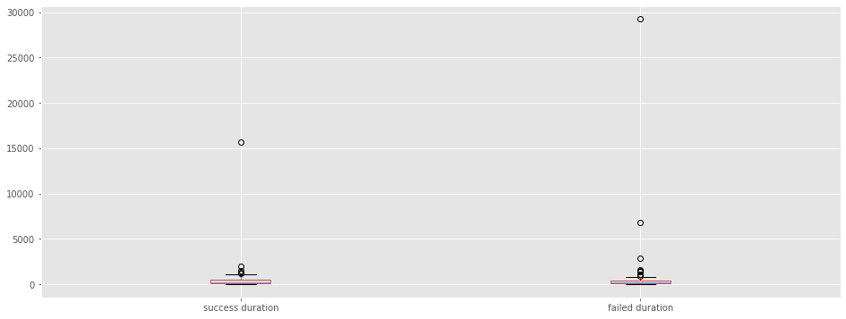

```python
#preview canter value
df_duration.boxplot(column=["success duration", "failed duration"], figsize=(16, 6))
```

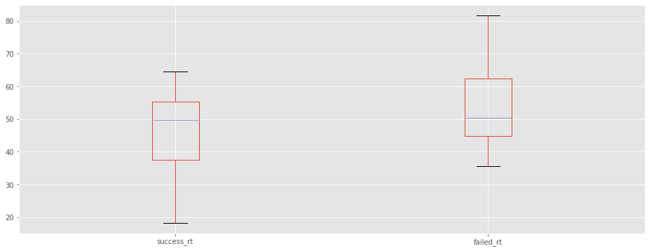

```python
#preview canter value
df_duration.boxplot(column=["success_rt", "failed_rt"], figsize=(16, 6))
```

```python
df_duration.describe()
```

|  | success duration | all duration | failed duration | success_rt | failed_rt |
| --- | --- | --- | --- | --- | --- |
| count | 62.000000 | 62.000000 | 62.000000 | 62.000000 | 62.000000 |
| mean | 615.677419 | 1553.629032 | 937.951613 | 47.085922 | 52.914078 |
| std | 1986.889478 | 5739.945085 | 3774.500056 | 11.679342 | 11.679342 |
| min | 1.000000 | 2.000000 | 1.000000 | 18.233105 | 35.530086 |
| 25% | 71.000000 | 175.500000 | 96.000000 | 37.611153 | 44.762307 |
| 50% | 199.500000 | 428.000000 | 179.500000 | 49.668351 | 50.331649 |
| 75% | 489.750000 | 899.250000 | 422.000000 | 55.237693 | 62.388847 |
| max | 15669.000000 | 44910.000000 | 29241.000000 | 64.469914 | 81.766895 |

## 4. Visualization of Correlation

This Correlation Tests will check if two variables of more have a linear relationship. For your information

- The dependent variable for the data used is the state variable.
- Independent variables for the data used are other than state variables. Like goals, pledged, backers, duration, month, category, country.

The data will use only data with 2 types of status namely successfull and failed, for the status of suspended, live and canceled will not be included in the hypothesis testing this time.

**Pearson’s Correlation Coefficient** Tests whether two samples have a linear relationship.

**Assumptions**

- Observations in each sample are independent.
- Observations in each sample are normally distributed.

**Interpretation**

- H0: the two samples are independent.
- H1: there is a dependency between the samples.

**Information about the Pearson correlation coefficient:**

- The Pearson correlation coefficient can take on any real value in the range −1 ≤ r ≤ 1.
- The maximum value r = 1 corresponds to the case when there’s a perfect positive linear relationship between x and y. In other words, larger x values correspond to larger y values and vice versa.
- The value r > 0 indicates positive correlation between x and y.
- The value r = 0 corresponds to the case when x and y are independent.
- The value r < 0 indicates negative correlation between x and y.
- The minimal value r = −1 corresponds to the case when there’s a perfect negative linear relationship between x and y. In other words, larger x values correspond to smaller y values and vice versa.

**Pearson's Correlation test**

By using a level of accuracy of 95% then:

if p > 0.05:

```
print('Probably independent')
```

else:

```
print('Probably dependent')
```

### 4.1 Hypothesis

- Is there a correlation between duration and project success?
- Is there a correlation between category and project success?
- Is there a correlation between backers and project success?
- Is there a correlation between pledged and project success?
- Is there a correlation between goal and project success?
- Is there a correlation between month and project success?
- Is there a correlation between country and project success?
- Clasification of successed project
- Create a model to predict if a project will be successful before it is released.

```python
#show dataframe that will be used
df_kickstarter.head(3)
```

|  | main_category | deadline | launched | state | backers | country | usd_pledged_real | usd_goal_real | year | duration | month_dl |
| --- | --- | --- | --- | --- | --- | --- | --- | --- | --- | --- | --- |
| 0 | Film & Video | 2017-11-01 | 2017-09-02 | failed | 15 | US | 2421.0 | 30000.0 | 2017 | 60.0 | 11 |
| 1 | Food | 2016-04-01 | 2016-02-26 | successful | 224 | US | 52375.0 | 50000.0 | 2016 | 35.0 | 4 |
| 2 | Food | 2016-03-17 | 2016-02-01 | failed | 40 | US | 453.0 | 25000.0 | 2016 | 45.0 | 3 |

### 4.2 Pearson’s Correlation Coefficient Tests

```python
#Create new data frame for successful and failed project state
successful = df_kickstarter.loc[df_kickstarter["state"] == "successful"]
failed = df_kickstarter.loc[df_kickstarter["state"] == "failed"]
df_row = pd.concat([successful, failed])

#Creating labelEncoder
encoder = preprocessing.LabelEncoder()

#Converting string labels into numbers.
df_row["state"]=encoder.fit_transform(df_row["state"])
df_row["country"] =  encoder.fit_transform(df_row["country"])
df_row["main_category"] =  encoder.fit_transform(df_row["main_category"])


category = df_row["main_category"]
state = df_row["state"]
duration = df_row["duration"]
goal = df_row["usd_goal_real"]
pledged = df_row["usd_pledged_real"]
backers =df_row["backers"]
month = df_row["month_dl"]
country = df_row["country"]

#Create Pandas objects
df_row = pd.DataFrame({'state': state,
                       'category': category,
                       'duration': duration,
                       'goal' : goal,
                       'pledged' : pledged,
                       'backers' : backers,
                       'month' : month,
                       'country' : country})
df_row.head(10)
```

|  | state | category | duration | goal | pledged | backers | month | country |
| --- | --- | --- | --- | --- | --- | --- | --- | --- |
| 1 | 1 | 7 | 35.0 | 50000.00 | 52375.00 | 224 | 4 | 22 |
| 4 | 1 | 8 | 28.0 | 6469.73 | 121857.33 | 761 | 5 | 9 |
| 7 | 1 | 1 | 30.0 | 142.91 | 160.60 | 27 | 1 | 9 |
| 8 | 1 | 6 | 30.0 | 50000.00 | 57577.31 | 840 | 5 | 22 |
| 9 | 1 | 4 | 31.0 | 1000.00 | 47266.00 | 549 | 10 | 22 |
| 11 | 1 | 10 | 11.0 | 2100.00 | 2100.00 | 34 | 12 | 22 |
| 25 | 1 | 8 | 30.0 | 5938.52 | 13347.43 | 346 | 11 | 12 |
| 26 | 1 | 12 | 30.0 | 1000.00 | 1055.00 | 19 | 12 | 22 |
| 28 | 1 | 7 | 34.0 | 20000.00 | 47273.00 | 1261 | 4 | 22 |
| 33 | 1 | 0 | 30.0 | 8000.00 | 8360.00 | 121 | 12 | 22 |

```python
#view encoded state, 0 for failed and 1 for successful
df_row["state"].value_counts()
```

```
0    58155
1    38172
Name: state, dtype: int64
```

```python
#Pearson’s Correlation Coefficient Tests
df_row.corr()
```

|  | state | category | duration | goal | pledged | backers | month | country |
| --- | --- | --- | --- | --- | --- | --- | --- | --- |
| state | 1.000000 | -0.067991 | -0.152513 | -0.025951 | 0.130220 | 0.157147 | 0.046227 | 0.014779 |
| category | -0.067991 | 1.000000 | 0.064222 | 0.000134 | 0.009971 | 0.001450 | -0.008496 | -0.021036 |
| duration | -0.152513 | 0.064222 | 1.000000 | 0.037663 | 0.019526 | 0.008703 | -0.030531 | -0.026098 |
| goal | -0.025951 | 0.000134 | 0.037663 | 1.000000 | 0.002180 | -0.000132 | -0.007090 | 0.005079 |
| pledged | 0.130220 | 0.009971 | 0.019526 | 0.002180 | 1.000000 | 0.735218 | 0.011270 | 0.021036 |
| backers | 0.157147 | 0.001450 | 0.008703 | -0.000132 | 0.735218 | 1.000000 | 0.012638 | 0.021221 |
| month | 0.046227 | -0.008496 | -0.030531 | -0.007090 | 0.011270 | 0.012638 | 1.000000 | -0.009648 |
| country | 0.014779 | -0.021036 | -0.026098 | 0.005079 | 0.021036 | 0.021221 | -0.009648 | 1.000000 |

**Pearson's Correlation value**

Based on information about Pearson's Correlation value, it can be seen from the table above that some independent variables have a correlation with the dependent variable. By using a level of accuracy of 95% then if r > 0.05 Probably positive correlation, else r < -0.05 Probably has negative correlation).

1. categories have a negative correlation with state variables (r = -0.067991)
2. duration has a negative correlation with state variables (r = -0.152513)
3. goal has no correlation with the state variable (r = -0.025951)
4. pledged has a positive correlation with state variables (r = 0.130220)
5. backers have a positive correlation with state variables (r = 0.157147)
6. month has no correlation with state variables (r = 0.046227)
7. country has no correlation with state variables (r = 0.014779)